# Lyrics Analysis using NLP in R

Dhrubasattwata Roy Choudhury

## Lyrics Analysis

Musical lyrics may represent an artist’s perspective, but popular songs reveal what society wants to hear. Predictive Lyrics is beginning to buzz and is more prevalent as a subject of research papers and graduate theses. This case study will just touch on a few pieces of this emerging subject.

### Import the packages

```r
library(dplyr) #data manipulation
```

```r
library(ggplot2) #visualizations
library(gridExtra) #viewing multiple plots together
library(tidytext) #text mining
library(widyr)
library(tidyr)
library(wordcloud2) #creative visualizations
library(tm) #text cleaning
library(knitr) # for dynamic reporting
library(kableExtra) # create a nicely formated HTML table
library(formattable)
library(ggrepel)
library(circlize) #Visualizations - chord diagram
library(memery) #Memes - images with plots
library(magick) #Memes - images with plots (image_read)
library(yarrr)  #Pirate plot
library(radarchart) #Visualizations
library(igraph) #ngram network diagrams
library(ggraph) #ngram network diagrams
library(radarchart)
library(topicmodels)
library(plotly)
library(cleanNLP)
library(mlr)
```

### Dataset

We will look into the work of John Mayer just because I like his music. I scraped off the data off the internet, and can be downloaded from the GitHub repo.

5 columns:  
lyrics - lyrics of the song  
song - name of the song  
year - year of the album  
album - name of the album  
peak - peak position in Billboard Chart

```r
johnmayer <- read.csv("C:/Users/Dhruba/Desktop/GitHub/R - GitHub/data/johnmayer_music.csv", stringsAsFactors = FALSE)
glimpse(johnmayer[10,])
```

```
## Rows: 1
## Columns: 5
## $ lyrics <chr> "We got the afternoon\nYou got this room for two\nOne thing ...
## $ song   <chr> "Your Body Is A Wonderland"
## $ year   <int> 2001
## $ album  <chr> "Room for Squares"
## $ peak   <int> 18
```

Trying to understand the dataset

```r
dim(johnmayer)
```

```
## [1] 94  5
```

94 songs, not bad.

Trying to look at the structure of the lyrics

```r
str(johnmayer[10,]$lyrics, nchar.max = 400)
```

```
##  chr "We got the afternoon\nYou got this room for two\nOne thing I've left to do\nDiscover me\nDiscovering you\n\nOne mile to every inch of\nYour skin like porcelain\nOne pair of candy lips and\nYour bubblegum tongue\n\nAnd if you want love\nWe'll make it\nSwim in a deep sea\nOf blankets\nTake al…
```

### Data Pre-processing

Getting rid of those pesky contractions by creating a little function that handles most scenarios using gsub(), and then apply that function across all lyrics.

```r
# function to expand contractions in an English-language source
fix.contractions <- function(doc) {
  # "won't" is a special case as it does not expand to "wo not"
  doc <- gsub("won't", "will not", doc)
  doc <- gsub("can't", "can not", doc)
  doc <- gsub("n't", " not", doc)
  doc <- gsub("'ll", " will", doc)
  doc <- gsub("'re", " are", doc)
  doc <- gsub("'ve", " have", doc)
  doc <- gsub("'m", " am", doc)
  doc <- gsub("'d", " would", doc)
  # 's could be 'is' or could be possessive: it has no expansion
  doc <- gsub("'s", "", doc)
  return(doc)
}

# fix (expand) contractions
johnmayer$lyrics <- sapply(johnmayer$lyrics, fix.contractions)
```

Getting rid of Special Characters

```r
# function to remove special characters
removeSpecialChars <- function(x) gsub("[^a-zA-Z0-9 ]", " ", x)
# remove special characters
johnmayer$lyrics <- sapply(johnmayer$lyrics, removeSpecialChars)
```

Converting everything to lower case

```r
johnmayer$lyrics <- sapply(johnmayer$lyrics, tolower)
```

Loooking at the lyrics again:

```r
str(johnmayer[10,]$lyrics, nchar.max = 400)
```

```
##  chr "we got the afternoon you got this room for two one thing i have left to do discover me discovering you  one mile to every inch of your skin like porcelain one pair of candy lips and your bubblegum tongue  and if you want love we will make it swim in a deep sea of blankets take all your big …
```

Overall Dataset summary statistics:

```r
summary(johnmayer)
```

```
##     lyrics              song                year         album
##  Length:94          Length:94          Min.   :1999   Length:94
##  Class :character   Class :character   1st Qu.:2003   Class :character
##  Mode  :character   Mode  :character   Median :2008   Mode  :character
##                                        Mean   :2008
##                                        3rd Qu.:2013
##                                        Max.   :2018
##
##       peak
##  Min.   :12.00
##  1st Qu.:18.50
##  Median :42.00
##  Mean   :47.21
##  3rd Qu.:74.00
##  Max.   :99.00
##  NA's   :75
```

A music career spanning 19 years. Let us make our life simpler and make it decades.

### Creating a Decade Column

```r
johnmayer <- johnmayer %>%
  mutate(decade =
                 ifelse(johnmayer$year %in% 1990:1999, "1990s",
                    ifelse(johnmayer$year %in% 2000:2009, "2000s",
                        ifelse(johnmayer$year %in% 2010:2019, "2010s",
                                              "NA"))))
glimpse(johnmayer[10,])
```

```
## Rows: 1
## Columns: 6
## $ lyrics <chr> "we got the afternoon you got this room for two one thing i ...
## $ song   <chr> "Your Body Is A Wonderland"
## $ year   <int> 2001
## $ album  <chr> "Room for Squares"
## $ peak   <int> 18
## $ decade <chr> "2000s"
```

Doing the same for the charts. Top 20, Top 100, Uncharted: which represents whether a song peaked in the Top 20, Top 100, or did not chart (that is, uncharted). These are mutually exclusive, so Top 100 does not include Top 20 songs. ### Create the chart_level

```r
johnmayer <- johnmayer%>%
  mutate(chart_level =
           ifelse(johnmayer$peak %in% 1:20, "Top 20",
                  ifelse(johnmayer$peak %in% 21:100, "Top 100", "Uncharted")))

head(johnmayer,10)
```

```
##                                                                                                                                                                                                                                                                                                          …
## 1                                                                                                                                                                                                                                                                                                        …
## 2   welcome to the real world   she said to me condescendingly take a seat take your life plot it out in black and white well i never lived the dreams of the prom kings and the drama queens i would like to think the best of me is still hiding up my sleeve  they love to tell you stay inside the li…
## 3                                                                                                                                 my stupid mouth has got me in trouble i said too much again to a date over dinner yesterday and i could see she was offended she said  well anyway     just dying for a…
## 4                                                                                                                                                                                                                                                                                                        …
## 5                                                                                                                                                                                                                                                                                                        …
## 6                                                                                                                i know you have been sworn i read your complaint you are needing someone older and though i have been warned to live day by day there something taking over  did you expect to kiss me o…
## 7                                                                                                                                                                                                                                                                                                        …
## 8                                                                                                                                                                                                                                                                                                        …
## 9                                                                                                                                                                                                                                                                                                        …
## 10                                                                                                                                                                                                                              we got the afternoon you got this room for two one thing i have left to d…
##                         song year            album peak decade chart_level
## 1                Back to you 1999 Inside Wants Out   NA  1990s   Uncharted
## 2              No Such Thing 1999 Inside Wants Out   13  1990s      Top 20
## 3            My Stupid Mouth 1999 Inside Wants Out   NA  1990s   Uncharted
## 4                       Neon 1999 Inside Wants Out   NA  1990s   Uncharted
## 5                   Victoria 1999 Inside Wants Out   NA  1990s   Uncharted
## 6                  Love Soon 1999 Inside Wants Out   NA  1990s   Uncharted
## 7                Comfortable 1999 Inside Wants Out   NA  1990s   Uncharted
## 8                      Quiet 1999 Inside Wants Out   NA  1990s   Uncharted
## 9                Why Georgia 2001 Room for Squares   NA  2000s   Uncharted
## 10 Your Body Is A Wonderland 2001 Room for Squares   18  2000s      Top 20
```

Create a binary field called charted indicating whether a song reached the Billboard charts or not (that is, a popular song).

```r
johnmayer <- johnmayer %>%
  mutate(charted =
           ifelse(johnmayer$peak %in% 1:100, "Charted", "Uncharted"))

#save the new dataset to .csv for later use
#write.csv(johnmayer, file = "C:/Users/Dhruba/Desktop/GitHub/R - GitHub/data/johnmayer_music_new.csv")
```

### Visualization

Defining a theme for visualization: theme_lyrics

```r
my_colors <- c("midnightblue", "orangered3", "darkgreen", "burlywood3", "cyan4")

theme_lyrics <- function()
{
  theme(plot.title = element_text(hjust = 0.5),
        axis.text.x = element_blank(),
        axis.ticks = element_blank(),
        panel.grid.major = element_blank(),
        panel.grid.minor = element_blank(),
        legend.position = "none")
}
```

Song Stats: Chartered and Uncharted across decades

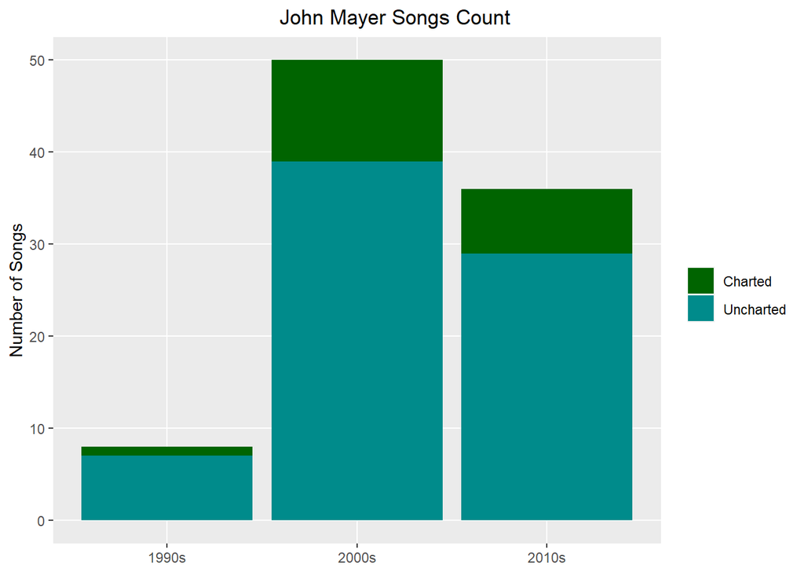

```r
johnmayer %>%
  filter(decade != "NA") %>%
  group_by(decade, charted) %>%
  summarise(number_of_songs = n()) %>%
  ggplot() +
  geom_bar(aes(x = decade, y = number_of_songs,
               fill = charted), stat = "identity")  +
  theme(plot.title = element_text(hjust = 0.6),
        legend.title = element_blank(),
        panel.grid.minor = element_blank()) +
  scale_fill_manual("legend", values = c("Charted" = "darkgreen", "Uncharted" = "cyan4")) +
  ggtitle("John Mayer Songs Count") +
  labs(x = NULL, y = "Number of Songs")
```

Clearly 2000-2010 was a major hit period for him. But comeon he is young.

Song Stats: Popular vs Very Popular

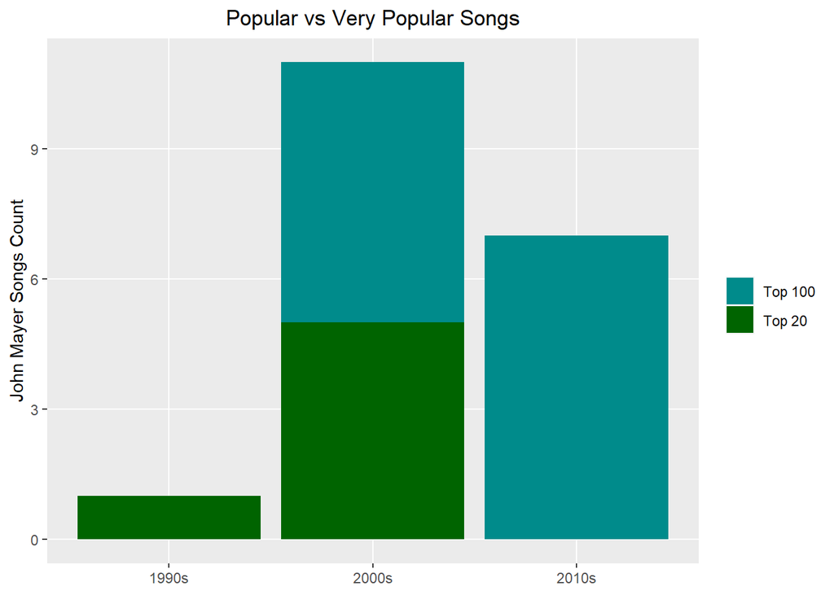

```r
charted_songs_over_time <- johnmayer %>%
  filter(peak > 0) %>%
  group_by(decade, chart_level) %>%
  summarise(number_of_songs = n())
charted_songs_over_time %>%
  ggplot() +
  geom_bar(aes(x = decade, y = number_of_songs,
               fill = chart_level), stat = "identity") +
  theme(plot.title = element_text(hjust = 0.5),
        legend.title = element_blank(),
        panel.grid.minor = element_blank()) +
  scale_fill_manual("legend", values = c("Top 20" = "darkgreen", "Top 100" = "cyan4")) +
  labs(x = NULL, y = "John Mayer Songs Count") +
  ggtitle("Popular vs Very Popular Songs")
```

Clearly 2000 - 2010 was golden for John Mayer. No Top 20 in 2010-2019. That is sad.

Song Stats: Over the entire span of career

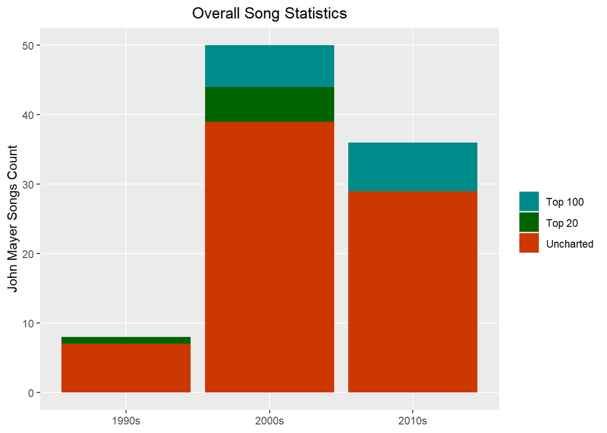

```r
johnmayer %>%
  group_by(decade, chart_level) %>%
  summarise(number_of_songs = n()) %>%
  ggplot() +
  geom_bar(aes(x = decade, y = number_of_songs,
               fill = chart_level), stat = "identity")  +
  theme(plot.title = element_text(hjust = 0.5),
        legend.title = element_blank(),
        panel.grid.minor = element_blank()) +
  scale_fill_manual("legend", values = c("Top 20" = "darkgreen", "Top 100" = "cyan4", "Uncharted" = "orangered3")) +
  labs(x = NULL, y = "John Mayer Songs Count") +
  ggtitle("Overall Song Statistics")
```

Best Songs of John Mayer’s Career

```r
johnmayer %>%
  filter(peak <= "20") %>%
  select(year, song, peak) %>%
  arrange(year) %>%
  mutate(year = color_tile("lightblue", "lightgreen")(year)) %>%
  mutate(peak = color_tile("lightgreen", "lightgreen")(peak)) %>%
  kable("html", escape = FALSE, align = "c", caption = "John Mayer's Most Popular Songs") %>%
  kable_styling(bootstrap_options =
                  c("striped", "condensed", "bordered"),
                full_width = FALSE)
```

John Mayer’s Most Popular Songs

| year | song | peak |
| --- | --- | --- |
| 1999 | No Such Thing | 13 |
| 2001 | Your Body Is A Wonderland | 18 |
| 2003 | Daughters | 19 |
| 2006 | Waiting On The World To Change | 14 |
| 2008 | Say | 12 |
| 2009 | Who Says | 17 |

### Text Analytics

Natural Language Processing (NLP) is one methodology used in mining text. It tries to decipher the ambiguities in written language by tokenization, clustering, extracting entity and word relationships, and using algorithms to identify themes and quantify subjective information. You’ll begin by breaking down the concept of lexical complexity.

Lexical complexity can mean different things in different contexts, but for now, assume that it can be described by a combination of these measures:  
Word Frequency: number of words per song  
Word Length: average length of individual words in a text  
Lexical Diversity: number of unique words used in a text (song vocabulary)  
Lexical Density: the number of unique words divided by the total number of words (word repetition)

A few words needs to be removed manually:

```r
undesirable_words <- c("prince", "chorus", "repeat", "lyrics",
                       "theres", "bridge", "fe0f", "yeah", "baby",
                       "alright", "wanna", "gonna", "chorus", "verse",
                       "whoa", "gotta", "make", "miscellaneous", "2",
                       "4", "ooh", "uurh", "pheromone", "poompoom", "3121",
                       "matic", " ai ", " ca ", " la ", "hey", " na ",
                       " da ", " uh ", " tin ", "  ll", "transcription",
                       "repeats")
```

From the tidy text framework, you need to both break the text into individual tokens (tokenization) and transform it to a tidy data structure. There are different lists to choose from, but use the lexicon called stop_words from the tidytext package.

1. Tokenize the Lyrics.
2. Use Anti_Join to remove the stop_words.
3. Remove Duplicates.
4. Store the results into johnmayer_words_filtered.

```r
#unnest and remove stop, undesirable and short words
johnmayer_words_filtered <- johnmayer %>%
  unnest_tokens(word, lyrics) %>%
  anti_join(stop_words) %>%
  distinct() %>%
  filter(!word %in% undesirable_words) %>%
  filter(nchar(word) > 3)
class(johnmayer_words_filtered)
```

```
## [1] "data.frame"
```

```r
dim(johnmayer_words_filtered)
```

```
## [1] 2884    8
```

### Word Frequency

In music, individual word frequencies carry a great deal of importance, whether it be repetition or rarity. Both affect memorability of the entire song itself. One question a songwriter may want to know is if there is a correlation between word frequency and hit songs. So now you want to take the tidy format one step further and get a summarized count of words per song.

Create a histogram showing the distribution of word counts, grouped by song, per placement on the Billboard Charts.

```r
full_word_count <- johnmayer %>%
  unnest_tokens(word, lyrics) %>%
  group_by(song,chart_level) %>%
  summarise(num_words = n()) %>%
  arrange(desc(num_words))
full_word_count[1:10,] %>%
  ungroup(num_words, song) %>%
  mutate(num_words = color_bar("lightblue")(num_words)) %>%
  mutate(song = color_tile("lightblue","lightblue")(song)) %>%
  kable("html", escape = FALSE, align = "c", caption = "Highest Word Count for Songs") %>%
  kable_styling(bootstrap_options =
                  c("striped", "condensed", "bordered"),
                full_width = FALSE)
```

Highest Word Count for Songs

| song | chart_level | num_words |
| --- | --- | --- |
| Split Screen Sadness | Uncharted | 387 |
| New Light | Uncharted | 336 |
| A Face To Call Home | Uncharted | 326 |
| Assassin | Uncharted | 326 |
| Half Of My Heart | Top 100 | 318 |
| Slow Dancing In A Burning Room | Uncharted | 316 |
| No Such Thing | Top 20 | 311 |
| Love Soon | Uncharted | 304 |
| Eighty Three | Uncharted | 302 |
| Home Life | Uncharted | 295 |

Histogram (Distribution of word count per song and popularity)

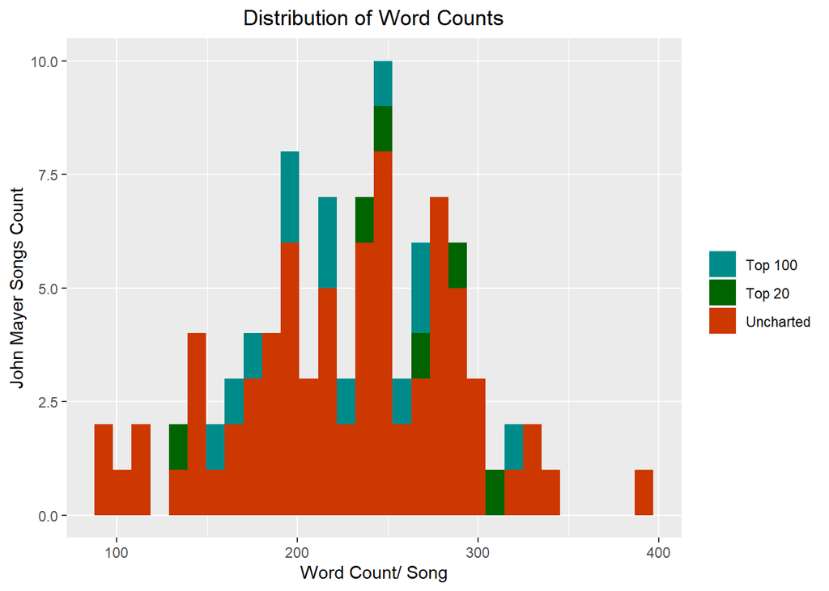

```r
full_word_count %>%
  ggplot() +
  geom_histogram(aes(x = num_words, fill = chart_level )) +
  scale_fill_manual("legend", values = c("Top 20" = "darkgreen", "Top 100" = "cyan4", "Uncharted" = "orangered3")) +
  ylab("John Mayer Songs Count") +
  xlab("Word Count/ Song") +
  ggtitle("Distribution of Word Counts") +
  theme(plot.title = element_text(hjust = 0.5),
        legend.title = element_blank(),
        panel.grid.minor.y = element_blank())
```

Most frquently used words

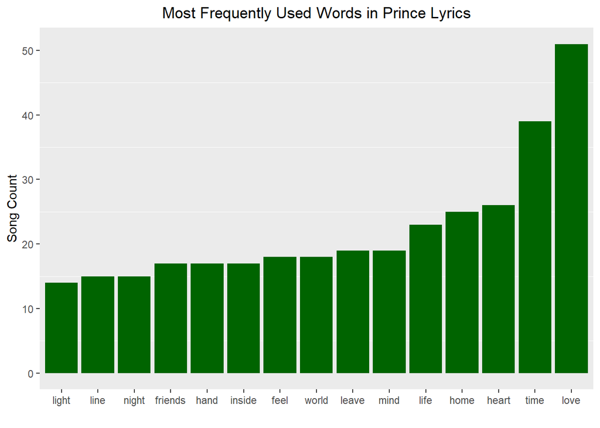

```r
johnmayer_words_filtered %>%
  count(word, sort = TRUE) %>%
  top_n(15) %>%
  ungroup() %>%
  mutate(word = reorder(word, n)) %>%
  ggplot() +
  geom_col(aes(word, n), fill = my_colors[3]) +
  theme(legend.position = "none",
        plot.title = element_text(hjust = 0.5),
        panel.grid.major = element_blank()) +
  xlab("") +
  ylab("Song Count") +
  ggtitle("Most Frequently Used Words in Prince Lyrics")
```

### Popular Words (10 most popular words by Type)

Popular Words are the top words across all songs by chart level.

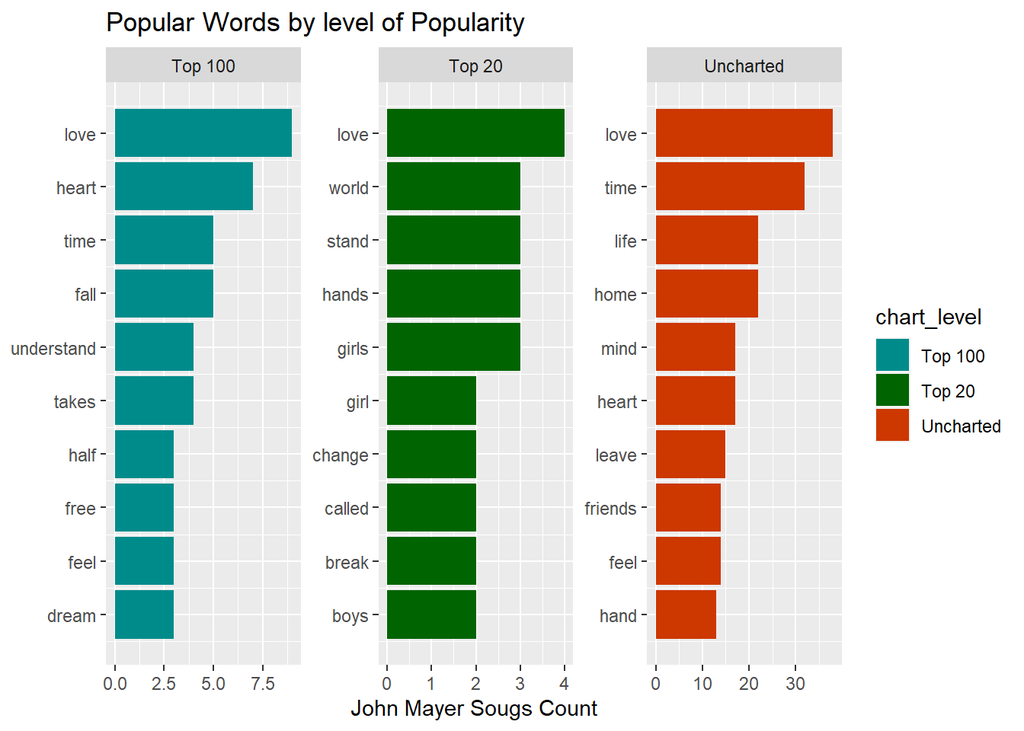

```r
popular_words <- johnmayer_words_filtered %>%
  group_by(chart_level) %>%
  count(word, chart_level, sort = TRUE) %>%
  slice(seq_len(10)) %>%
  ungroup() %>%
  arrange(chart_level,n) %>%
  mutate(row = row_number())

popular_words %>%
  ggplot(aes(row, n, fill = chart_level)) +
  geom_col() +
  labs(x = NULL, y = "John Mayer Sougs Count") +
  ggtitle("Popular Words by level of Popularity") +
  scale_fill_manual(values = c("Top 20" = "darkgreen", "Top 100" = "cyan4", "Uncharted" = "orangered3")) +
  facet_wrap(~chart_level, scales = "free") +
  scale_x_continuous(  # This handles replacement of row
    breaks = popular_words$row, # notice need to reuse data frame
    labels = popular_words$word) +
  coord_flip()
```

### Timeless Words (Top 10)

Some words in music are considered to be timeless. Timeless words persevere over time, appealing to a large audience. If you break down your analysis across decades, these words roll to the top.

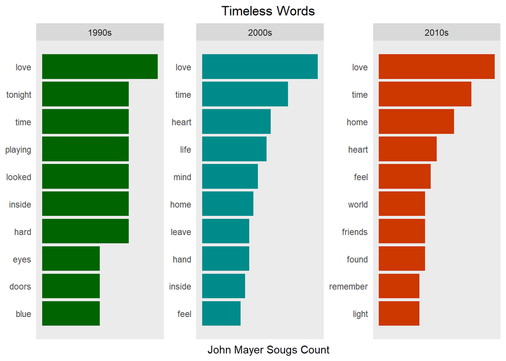

```r
timeless_words <- johnmayer_words_filtered %>%
  filter(decade != 'NA') %>%
  group_by(decade) %>%
  count(word, decade, sort = TRUE) %>%
  slice(seq_len(10)) %>%
  ungroup() %>%
  arrange(decade,n) %>%
  mutate(row = row_number())

timeless_words %>%
  ggplot(aes(row, n, fill = decade)) +
  geom_col() +
  labs(x = NULL, y = "John Mayer Sougs Count") +
  ggtitle("Timeless Words") +
  scale_fill_manual(values = c("1990s" = "darkgreen", "2000s" = "cyan4", "2010s" = "orangered3")) +
  theme_lyrics() +
  facet_wrap(~decade, scales = "free", ncol = 5) +
  scale_x_continuous(  # This handles replacement of row
    breaks = timeless_words$row, # notice need to reuse data frame
    labels = timeless_words$word) +
  coord_flip()
```

### Word Length

Word length is an interesting topic for songwriters. The longer the word, the harder it is to rhyme and squeeze into a pattern.

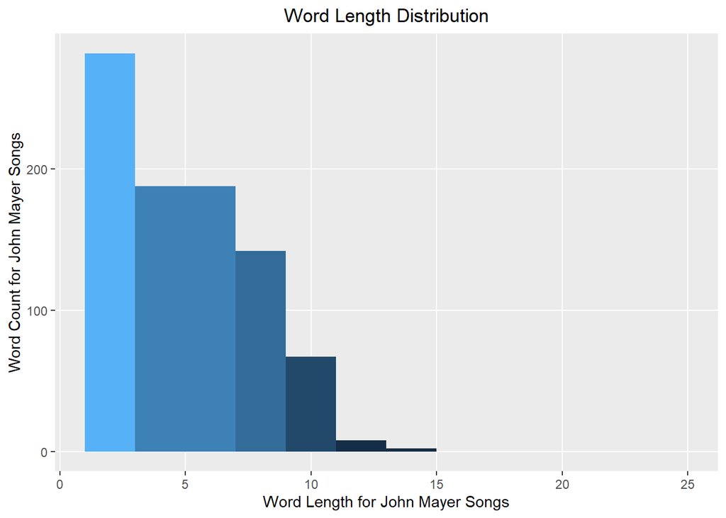

```r
johnmayer_word_lengths <- johnmayer %>%
  unnest_tokens(word, lyrics) %>%
  group_by(song,decade) %>%
  distinct() %>%
  filter(!word %in% undesirable_words) %>%
  mutate(word_length = nchar(word))

johnmayer_word_lengths %>%
  count(word_length, sort = TRUE) %>%
  ggplot(aes(word_length),
         binwidth = 10) +
  geom_histogram(aes(fill = ..count..),
                 breaks = seq(1,25, by = 2),
                 show.legend = FALSE) +
  xlab("Word Length for John Mayer Songs") +
  ylab("Word Count for John Mayer Songs") +
  ggtitle("Word Length Distribution") +
  theme(plot.title = element_text(hjust = 0.5),
        panel.grid.minor = element_blank())
```

### Lexical Diversity

The more varied a vocabulary a text possesses, the higher its lexical diversity. Song Vocabulary is a representation of how many unique words are used in a song. This can be shown with a simple graph of the average unique words per song over the years. You’ll want to tokenize the original dataset again but leave in all stop and short words since you’re looking more at quantitative insights in this plot.

```r
lex_diversity_per_year <- johnmayer %>%
  filter(decade != "NA") %>%
  unnest_tokens(word, lyrics) %>%
  group_by(song,year) %>%
  summarise(lex_diversity = n_distinct(word)) %>%
  arrange(desc(lex_diversity))
```

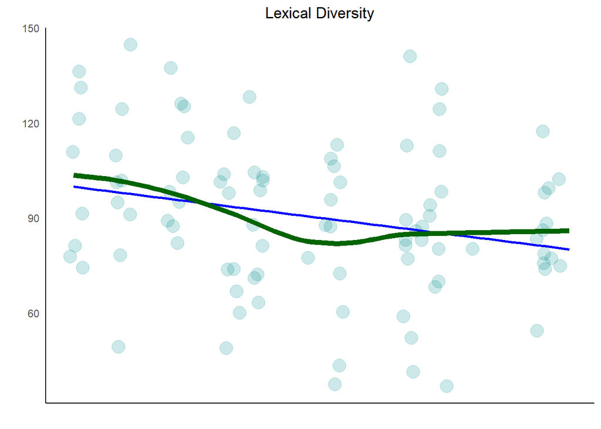

```r
diversity_plot <- lex_diversity_per_year %>%
  ggplot(aes(year, lex_diversity)) +
  geom_point(color = "cyan4",
             alpha = .2,
             size = 5,
             position = "jitter") +
  stat_smooth(color = "blue", se = FALSE, method = "lm") +
  geom_smooth(aes(x = year, y = lex_diversity), se = FALSE,
              color = "darkgreen", lwd = 2) +
  ggtitle("Lexical Diversity") +
  xlab("") +
  ylab("") +
  scale_color_manual(values = my_colors) +
  theme_classic() +
  theme_lyrics()

diversity_plot
```

### Lexical Density

Lexical density is defined as the number of unique words divided by the total number of words. This is an indicator of word repetition, which is a critical songwriter’s tool. As lexical density increases, repetition decreases.

```r
lex_density_per_year <- johnmayer %>%
  filter(decade != "NA") %>%
  unnest_tokens(word, lyrics) %>%
  group_by(song,year) %>%
  summarise(lex_density = n_distinct(word)/n()) %>%
  arrange(desc(lex_density))
```

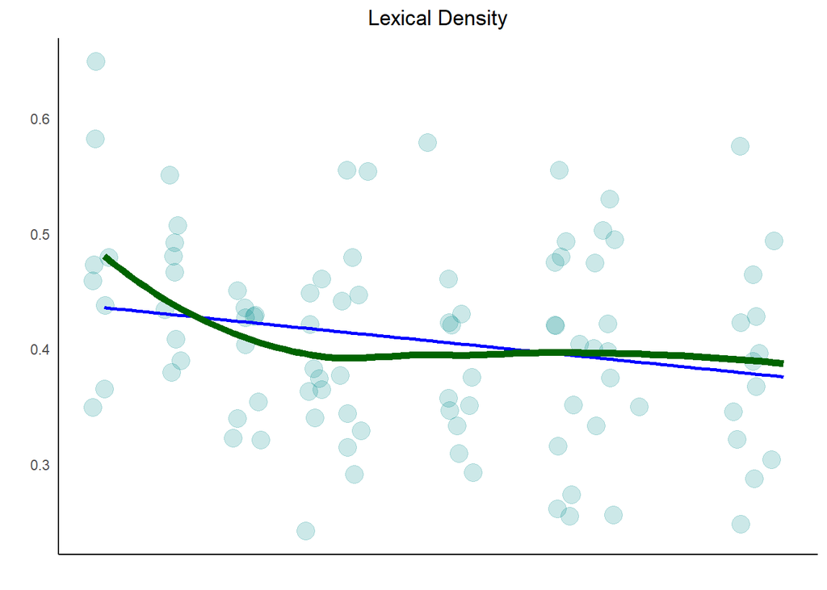

```r
density_plot <- lex_density_per_year %>%
  ggplot(aes(year, lex_density)) +
  geom_point(color = "cyan4",
             alpha = .2,
             size = 5,
             position = "jitter") +
  stat_smooth(color = "blue",
              se = FALSE,
              method = "lm") +
  geom_smooth(aes(x = year, y = lex_density),
              se = FALSE,
              color = "darkgreen",
              lwd = 2) +
  ggtitle("Lexical Density") +
  xlab("") +
  ylab("") +
  scale_color_manual(values = my_colors) +
  theme_classic() +
  theme_lyrics()

density_plot
```

In order to compare the trends, create a plot for his chart history (i.e. successful songs that reached the charts) and compare it to diversity and density.

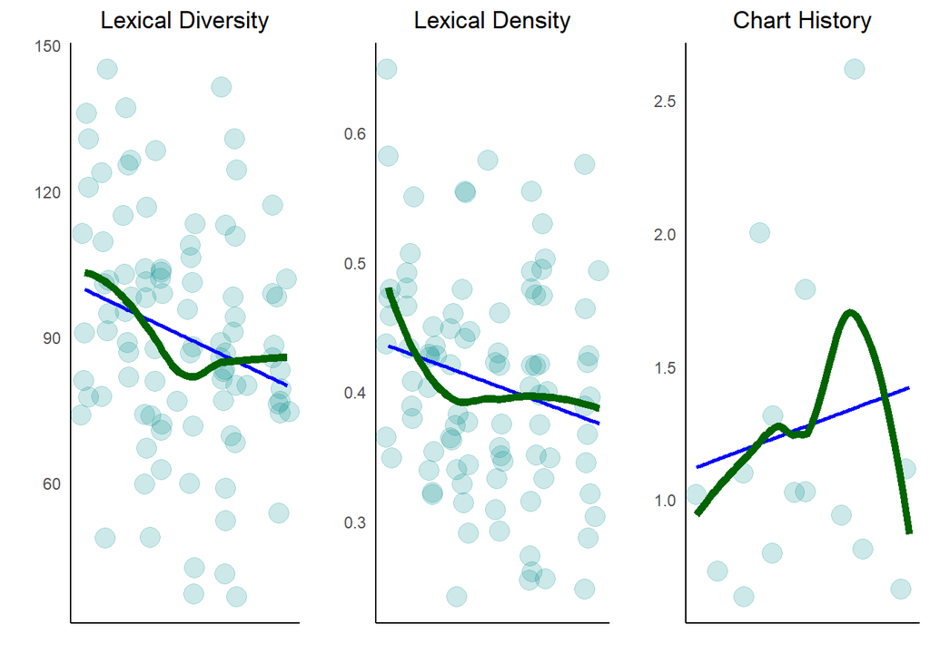

```r
chart_history <- johnmayer %>%
  filter(peak > 0) %>%
  group_by(year, chart_level) %>%
  summarise(number_of_songs = n()) %>%
  ggplot(aes(year, number_of_songs)) +
  geom_point(color = "cyan4",
             alpha = .2,
             size = 5,
             position = "jitter") +
  geom_smooth(aes(x = year, y = number_of_songs),
              se = FALSE,
              method = "lm",
              color = "blue" ) +
  geom_smooth(aes(x = year, y = number_of_songs),
              se = FALSE,
              color = "darkgreen",
              lwd = 2) +
  ggtitle("Chart History") +
  xlab("") +
  ylab("") +
  scale_color_manual(values = my_colors) +
  theme_classic() +
  theme_lyrics()
# Comparison
grid.arrange(diversity_plot, density_plot, chart_history, ncol = 3)
```

From the above, you see that there is a slight decrease in John Mayer’s lexical diversity and density over the years. How does this trend compare to all popular music? One study shows that Hit Songs have seen a declining lexical density, indicating increased repetition. The trend in similar.

## TF-IDF: TF is “term frequency”. IDF is “inverse document frequency”

The method that we used so far looks at the entire dataset, but it has not addressed how to quantify just how important various terms are in a document with respect to an entire collection. You have looked at term frequency, and removed stop words, but this may not be the most sophisticated approach.

We will use bind_tf_idf() from tidytext package.

```r
popular_tfidf_words <- johnmayer %>%
  unnest_tokens(word, lyrics) %>%
  distinct() %>%
  filter(!word %in% undesirable_words) %>%
  filter(nchar(word) > 3) %>%
  count(chart_level, word, sort = TRUE) %>%
  ungroup() %>%
  bind_tf_idf(word, chart_level, n)

head(popular_tfidf_words)
```

```
##   chart_level word  n          tf idf tf_idf
## 1   Uncharted that 52 0.011948529   0      0
## 2   Uncharted just 50 0.011488971   0      0
## 3   Uncharted will 45 0.010340074   0      0
## 4   Uncharted have 42 0.009650735   0      0
## 5   Uncharted when 42 0.009650735   0      0
## 6   Uncharted your 42 0.009650735   0      0
```

IDF and TF-IDF are 0 for extremely common words.

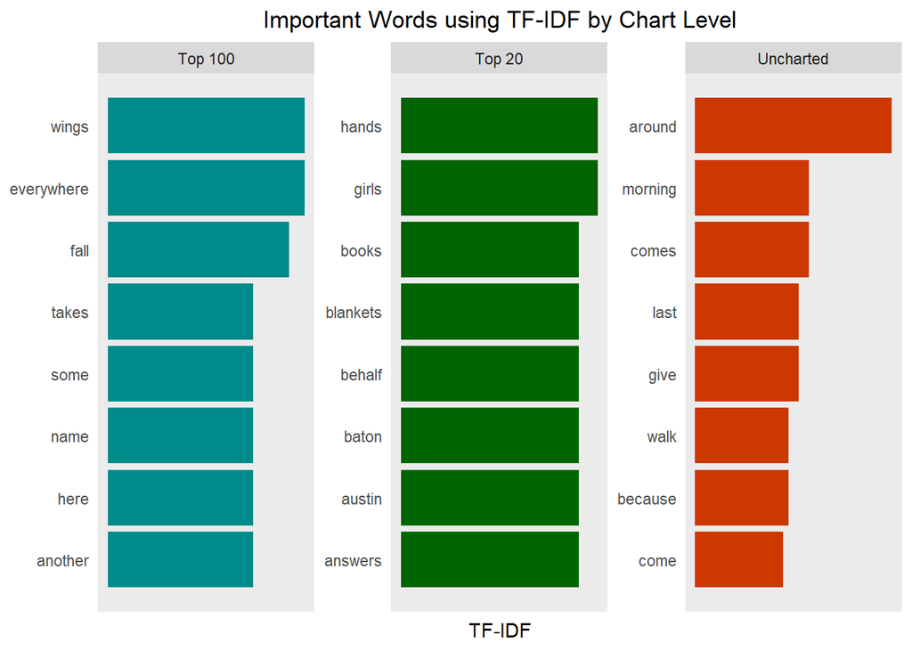

```r
top_popular_tfidf_words <- popular_tfidf_words %>%
  arrange(desc(tf_idf)) %>%
  mutate(word = factor(word, levels = rev(unique(word)))) %>%
  group_by(chart_level) %>%
  slice(seq_len(8)) %>%
  ungroup() %>%
  arrange(chart_level, tf_idf) %>%
  mutate(row = row_number())

top_popular_tfidf_words %>%
  ggplot(aes(x = row, tf_idf,
             fill = chart_level)) +
  geom_col(show.legend = NULL) +
  labs(x = NULL, y = "TF-IDF") +
  ggtitle("Important Words using TF-IDF by Chart Level") +
  scale_fill_manual(values = c("Top 20" = "darkgreen", "Top 100" = "cyan4", "Uncharted" = "orangered3")) +
  theme_lyrics() +
  facet_wrap(~chart_level, ncol = 3, scales = "free") +
  scale_x_continuous(  # This handles replacement of row
    breaks = top_popular_tfidf_words$row, # notice need to reuse data frame
    labels = top_popular_tfidf_words$word) +
  coord_flip()
```

Using TF-IDF certainly gives us a different perspective on potentially important words. Of course, the interpretation is purely subjective.

Take a look at the TF-IDF across time

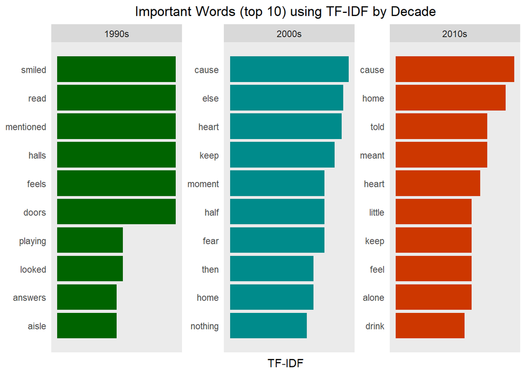

```r
tfidf_words_decade <- johnmayer %>%
  unnest_tokens(word, lyrics) %>%
  distinct() %>%
  filter(!word %in% undesirable_words & decade != 'NA') %>%
  filter(nchar(word) > 3) %>%
  count(decade, word, sort = TRUE) %>%
  ungroup() %>%
  bind_tf_idf(word, decade, n) %>%
  arrange(desc(tf_idf))

top_tfidf_words_decade <- tfidf_words_decade %>%
  group_by(decade) %>%
  slice(seq_len(10)) %>%
  ungroup() %>%
  arrange(decade, tf_idf) %>%
  mutate(row = row_number())

top_tfidf_words_decade %>%
  ggplot(aes(x = row, tf_idf, fill = decade)) +
  geom_col(show.legend = NULL) +
  labs(x = NULL, y = "TF-IDF") +
  ggtitle("Important Words (top 10) using TF-IDF by Decade") +
  scale_fill_manual(values = c("1990s" = "darkgreen", "2000s" = "cyan4", "2010s" = "orangered3")) +
  theme_lyrics() +
  facet_wrap(~decade,
             ncol = 3, nrow = 2,
             scales = "free") +
  scale_x_continuous(  # this handles replacement of row
    breaks = top_tfidf_words_decade$row, # notice need to reuse data frame
    labels = top_tfidf_words_decade$word) +
  coord_flip()
```

### Sentiment Analysis

Sentiment Analysis Overview

1. Methods: Sentiment analysis is a type of text mining which aims to determine the opinion and subjectivity of its content. When applied to lyrics, the results can be representative of not only the artist’s attitudes, but can also reveal pervasive, cultural influences. There are different methods used for sentiment analysis, including training a known dataset, creating your own classifiers with rules, and using predefined lexical dictionaries (lexicons). We will use the Lexicon-approach.
2. Levels: Just as there are different methods used for sentiment analysis, there are also different levels of analysis based on the text. These levels are typically identified as document, sentence, and word. In lyrics, the document could be defined as sentiment per decade, year, chart-level, or song. The sentence level is not usually an option with lyrics as punctuation can detract from rhymes and patterns. Word level analysis exposes detailed information and can be used as foundational knowledge for more advanced practices in topic modeling.

A few to keep in mind:  
1. is it possible to write a program to determine the mood expressed in lyrics? 2. Are predefined lexicons sufficient? How much data preparation is necessary?  
3. Can you link your results to real-life events? Does sentiment change over time?  
4. Are hit songs more positive or negative than uncharted songs?

### Visualization Defauls

```r
theme_lyrics <- function(aticks = element_blank(),
                         pgminor = element_blank(),
                         lt = element_blank(),
                         lp = "none")
{
  theme(plot.title = element_text(hjust = 0.5), #Center the title
        axis.ticks = aticks, #Set axis ticks to on or off
        panel.grid.minor = pgminor, #Turn the minor grid lines on or off
        legend.title = lt, #Turn the legend title on or off
        legend.position = lp) #Turn the legend on or off
}

#Customize the text tables for consistency using HTML formatting
my_kable_styling <- function(dat, caption) {
  kable(dat, "html", escape = FALSE, caption = caption) %>%
    kable_styling(bootstrap_options = c("striped", "condensed", "bordered"),
                  full_width = FALSE)
}
```

### Redefining Dataset for storing original

```r
johnmayer_data <- johnmayer
```

### Data Cleaning before Analysis

1. Removing Undesirable Words - Already defined as undesirable_words
2. Remove stop words
3. Remove words with fewer than three characters (often used for phonetic effect in music)
4. Split the lyrics into individual words

```r
johnmayer_tidy <- johnmayer_data %>%
  unnest_tokens(word, lyrics) %>% #Break the lyrics into individual words
  filter(!word %in% undesirable_words) %>% #Remove undesirables
  filter(!nchar(word) < 3) %>% #Words like "ah" or "oo" used in music
  anti_join(stop_words) #Data provided by the tidytext package
glimpse(johnmayer_tidy)
```

```
## Rows: 5,215
## Columns: 8
## $ song        <chr> "Back to you", "Back to you", "Back to you", "Back to y...
## $ year        <int> 1999, 1999, 1999, 1999, 1999, 1999, 1999, 1999, 1999, 1...
## $ album       <chr> "Inside Wants Out", "Inside Wants Out", "Inside Wants O...
## $ peak        <int> NA, NA, NA, NA, NA, NA, NA, NA, NA, NA, NA, NA, NA, NA,...
## $ decade      <chr> "1990s", "1990s", "1990s", "1990s", "1990s", "1990s", "...
## $ chart_level <chr> "Uncharted", "Uncharted", "Uncharted", "Uncharted", "Un...
## $ charted     <chr> "Uncharted", "Uncharted", "Uncharted", "Uncharted", "Un...
## $ word        <chr> "forget", "stay", "late", "move", "move", "forgetting",...
```

### Descriptive Statistics: Rechecking

Word Count Per Song by Popularity

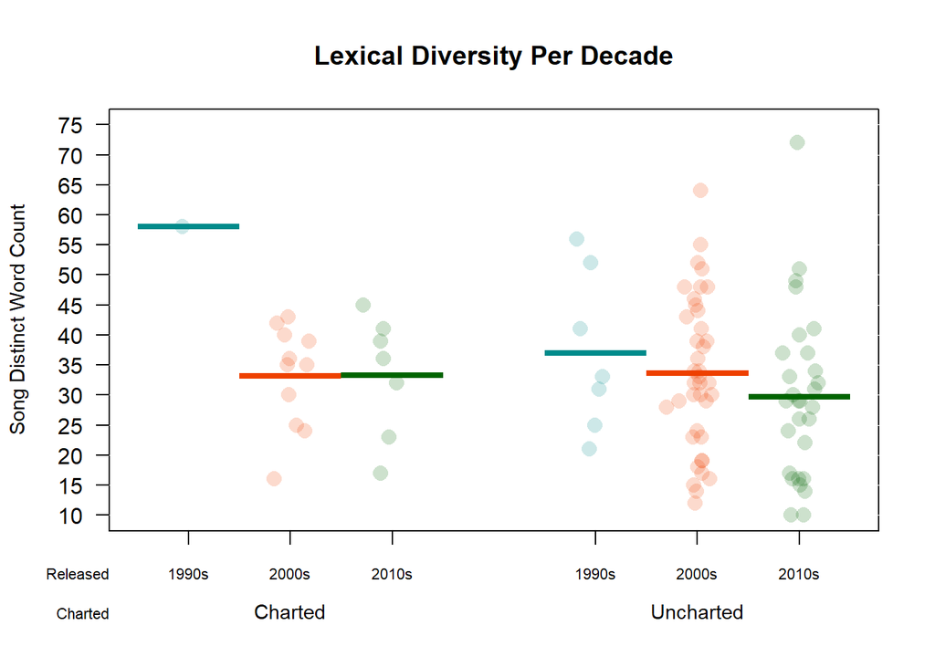

```r
word_summary <- johnmayer_tidy %>%
  mutate(decade = ifelse(is.na(decade),"NONE", decade)) %>%
  group_by(decade, song) %>%
  mutate(word_count = n_distinct(word)) %>%
  select(song, Released = decade, Charted = charted, word_count) %>%
  distinct() %>% #To obtain one record per song
  ungroup()

pirateplot(formula =  word_count ~ Released + Charted, #Formula
           data = word_summary, #Data frame
           xlab = NULL, ylab = "Song Distinct Word Count", #Axis labels
           main = "Lexical Diversity Per Decade", #Plot title
           pal = c("cyan4","orangered2","darkgreen"), #Color scheme
           point.o = .2, #Points
           avg.line.o = 1, #Turn on the Average/Mean line
           theme = 0, #Theme
           point.pch = 16, #Point `pch` type
           point.cex = 1.5, #Point size
           jitter.val = .1, #Turn on jitter to see the songs better
           cex.lab = .9, cex.names = .7) #Axis label size
```

### Song Count Per Year

```r
songs_year <- johnmayer_data %>%
  select(song, year) %>%
  group_by(year) %>%
  summarise(song_count = n())
```

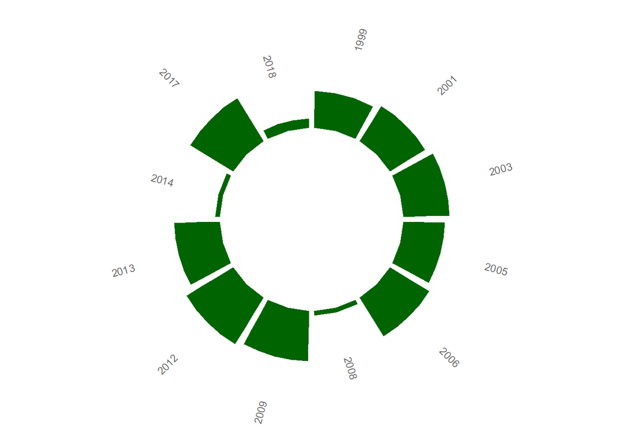

```r
id <- seq_len(nrow(songs_year))
songs_year <- cbind(songs_year, id)
label_data = songs_year
number_of_bar = nrow(label_data) #Calculate the ANGLE of the labels
angle = 90 - 360 * (label_data$id - 0.5) / number_of_bar #Center things
label_data$hjust <- ifelse(angle < -90, 1, 0) #Align label
label_data$angle <- ifelse(angle < -90, angle + 180, angle) #Flip angle

ggplot(songs_year, aes(x = as.factor(id), y = song_count)) +
  geom_bar(stat = "identity", fill = "darkgreen" ) +
  geom_text(data = label_data, aes(x = id, y = song_count + 10, label = year, hjust = hjust), color = "black", alpha = 0.6, size = 3, angle =  label_data$angle, inherit.aes = FALSE ) +
  coord_polar(start = 0) +
  ylim(-20, 80) + #Size of the circle
  theme_minimal() +
  theme(axis.text = element_blank(),
        axis.title = element_blank(),
        panel.grid = element_blank(),
        plot.margin = unit(rep(-4,4), "in"),
        plot.title = element_text(margin = margin(t = 10, b = -10)))
```

Popularity and Decade

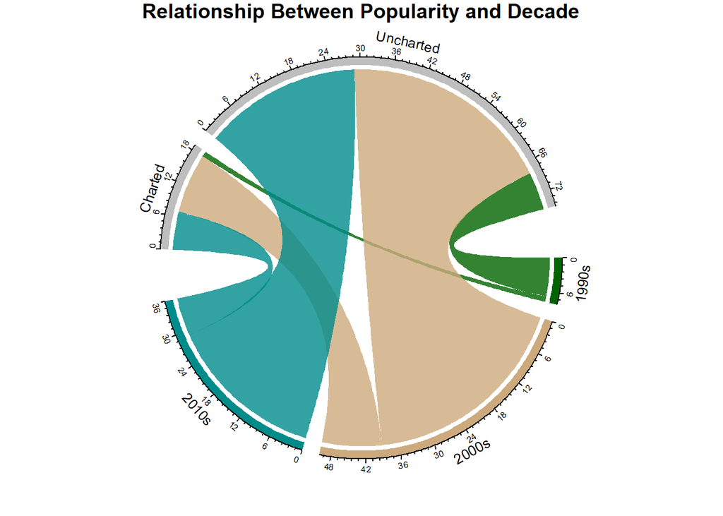

```r
decade_chart <-  johnmayer_data %>%
  filter(decade != "NA") %>% #Remove songs without release dates
  count(decade, charted)  #Get SONG count per chart level per decade. Order determines top or bottom.

circos.clear() #Very important - Reset the circular layout parameters!
grid.col = c("1970s" = my_colors[1], "1980s" = my_colors[2], "1990s" = my_colors[3], "2000s" = my_colors[4], "2010s" = my_colors[5], "Charted" = "grey", "Uncharted" = "grey") #assign chord colors
# Set the global parameters for the circular layout. Specifically the gap size
circos.par(gap.after = c(rep(5, length(unique(decade_chart[[1]])) - 1), 15,
                         rep(5, length(unique(decade_chart[[2]])) - 1), 15))

chordDiagram(decade_chart, grid.col = grid.col, transparency = .2)
title("Relationship Between Popularity and Decade")
```

### Lexicons and Lyrics

Import lexicon from tidytext package. We are going to use the “AFINN” pacakge.

```r
afinn <- tidytext::get_sentiments("afinn")
bing <- tidytext::get_sentiments("bing")
nrc <- tidytext::get_sentiments("nrc")

afinn <- afinn %>%
  mutate(lexicon = "AFINN") %>%
  mutate(sentiment = ifelse(value>=0, "positive","negative"))

afinn <- select(afinn,c(1,4,3))

bing <- bing %>%
  mutate(lexicon = "bing")
nrc <- nrc %>%
  mutate(lexicon = "nrc")

sentiments <- rbind(afinn,bing,nrc)

new_sentiments <- sentiments %>% #From the tidytext package
  group_by(lexicon) %>%
  mutate(words_in_lexicon = n_distinct(word)) %>%
  ungroup()


new_sentiments %>%
  group_by(lexicon, sentiment, words_in_lexicon) %>%
  summarise(distinct_words = n_distinct(word)) %>%
  ungroup() %>%
  spread(sentiment, distinct_words) %>%
  mutate(lexicon = color_tile("lightblue", "lightblue")(lexicon),
         words_in_lexicon = color_bar("lightgreen")(words_in_lexicon)) %>%
  my_kable_styling(caption = "Word Counts by Lexicon")
```

Word Counts by Lexicon

| lexicon | words_in_lexicon | anger | anticipation | disgust | fear | joy | negative | positive | sadness | surprise | trust |
| --- | --- | --- | --- | --- | --- | --- | --- | --- | --- | --- | --- |
| AFINN | 2477 | NA | NA | NA | NA | NA | 1598 | 879 | NA | NA | NA |
| bing | 6783 | NA | NA | NA | NA | NA | 4781 | 2005 | NA | NA | NA |
| nrc | 6468 | 1247 | 839 | 1058 | 1476 | 689 | 3324 | 2312 | 1191 | 534 | 1231 |

### Match Dot Common

In order to determine which lexicon is more applicable to the lyrics, you’ll want to look at the match ratio of words that are common to both the lexicon and the lyrics.

```r
johnmayer_tidy %>%
  mutate(words_in_lyrics = n_distinct(word)) %>%
  inner_join(new_sentiments) %>%
  group_by(lexicon, words_in_lyrics, words_in_lexicon) %>%
  summarise(lex_match_words = n_distinct(word)) %>%
  ungroup() %>%
  mutate(total_match_words = sum(lex_match_words), #Not used but good to have
         match_ratio = lex_match_words / words_in_lyrics) %>%
  select(lexicon, lex_match_words,  words_in_lyrics, match_ratio) %>%
  mutate(lex_match_words = color_bar("lightblue")(lex_match_words),
         lexicon = color_tile("lightgreen", "lightgreen")(lexicon)) %>%
  my_kable_styling(caption = "Lyrics Found In Lexicons")
```

Lyrics Found In Lexicons

| lexicon | lex_match_words | words_in_lyrics | match_ratio |
| --- | --- | --- | --- |
| AFINN | 230 | 1464 | 0.1571038 |
| bing | 270 | 1464 | 0.1844262 |
| nrc | 390 | 1464 | 0.2663934 |

The NRC lexicon has more of the distinct words from the lyrics than AFINN or Bing. Notice the sum of the match ratios is low. No lexicon could have all words, nor should they. Many words are considered neutral and would not have an associated sentiment.

#### More Data Preparation

It may be the case that you need a few more data preparation steps. Here are three techniques to consider before performing sentiment analysis:

Stemming: generally refers to removing suffixes from words to get the common origin  
Lemmatization: reducing inflected (or sometimes derived) words to their word stem, base or root form  
Word replacement: replace words with more frequently used synonyms

### Detailed Analysis

Using a foundational understanding of the dataset and the lexicons, apply that knowledge by joining them together for analysis. Here are the high-level steps you’ll take:

1. Create lexicon-specific datasets.
2. Look at polar sentiment across all songs.
3. Examine sentiment change over time.
4. Study song level sentiment.
5. Review how pairs of words affect sentiment.

Create Sentiment Datasets

```r
johnmayer_bing <- johnmayer_tidy %>%
  inner_join(get_sentiments("bing"))
johnmayer_nrc <- johnmayer_tidy %>%
  inner_join(get_sentiments("nrc"))
johnmayer_nrc_sub <- johnmayer_tidy %>%
  inner_join(get_sentiments("nrc")) %>%
  filter(!sentiment %in% c("positive", "negative"))
```

Visualize

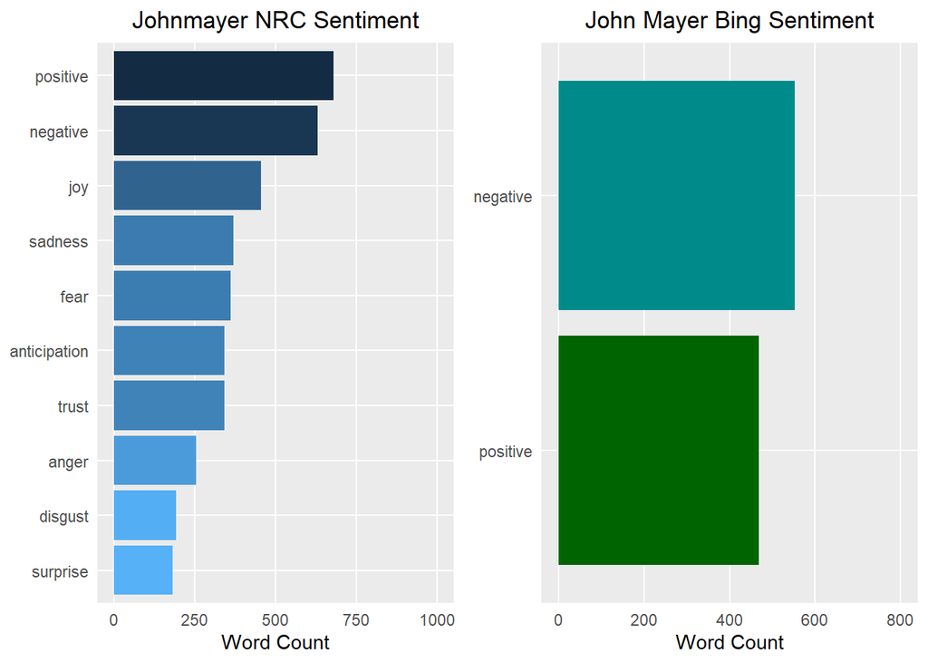

```r
nrc_plot <- johnmayer_nrc %>%
  group_by(sentiment) %>%
  summarise(word_count = n()) %>%
  ungroup() %>%
  mutate(sentiment = reorder(sentiment, word_count)) %>%
  #Use `fill = -word_count` to make the larger bars darker
  ggplot(aes(sentiment, word_count, fill = -word_count)) +
  geom_col() +
  guides(fill = FALSE) + #Turn off the legend
  theme_lyrics() +
  labs(x = NULL, y = "Word Count") +
  scale_y_continuous(limits = c(0, 1000)) + #Hard code the axis limit
  ggtitle("Johnmayer NRC Sentiment") +
  coord_flip()
bing_plot <- johnmayer_bing %>%
  group_by(sentiment) %>%
  summarise(word_count = n()) %>%
  ungroup() %>%
  mutate(sentiment = reorder(sentiment, word_count)) %>%
  ggplot(aes(sentiment, word_count, fill = sentiment)) +
  geom_col() +
  guides(fill = FALSE) +
  theme_lyrics() +
  labs(x = NULL, y = "Word Count") +
  scale_y_continuous(limits = c(0, 800)) +
  ggtitle("John Mayer Bing Sentiment")  +
  scale_fill_manual(values = c("positive" = "darkgreen", "negative" = "cyan4")) +
  coord_flip()
grid.arrange(nrc_plot,bing_plot,ncol=2)
```

Positivity and Negativity across Popularity. Breaking it down to the chart level using the Bing lexicon. Create a graph of the polar sentiment per chart level. Use spread() to separate the sentiments into columns and mutate() to create a polarity (positive - negative) field and a percent_positive field (positive/totalsentiment∗100), for a different perspective.

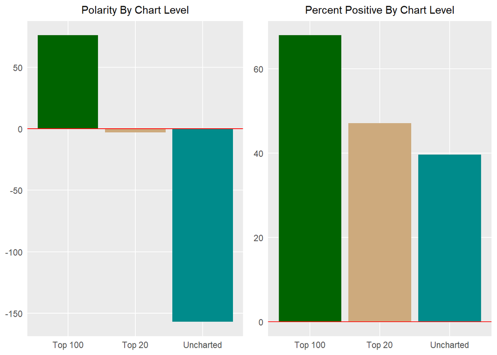

```r
johnmayer_polarity_chart <- johnmayer_bing %>%
  count(sentiment, chart_level) %>%
  spread(sentiment, n, fill = 0) %>%
  mutate(polarity = positive - negative,
         percent_positive = positive / (positive + negative) * 100)

#Polarity by chart
plot1 <- johnmayer_polarity_chart %>%
  ggplot( aes(chart_level, polarity, fill = chart_level)) +
  geom_col() +
  scale_fill_manual(values = my_colors[3:5]) +
  geom_hline(yintercept = 0, color = "red") +
  theme_lyrics() + theme(plot.title = element_text(size = 11)) +
  xlab(NULL) + ylab(NULL) +
  ggtitle("Polarity By Chart Level")

#Percent positive by chart
plot2 <- johnmayer_polarity_chart %>%
  ggplot( aes(chart_level, percent_positive, fill = chart_level)) +
  geom_col() +
  scale_fill_manual(values = c(my_colors[3:5])) +
  geom_hline(yintercept = 0, color = "red") +
  theme_lyrics() + theme(plot.title = element_text(size = 11)) +
  xlab(NULL) + ylab(NULL) +
  ggtitle("Percent Positive By Chart Level")

grid.arrange(plot1, plot2, ncol = 2)
```

Are the popular songs more positive?

Mood Ring

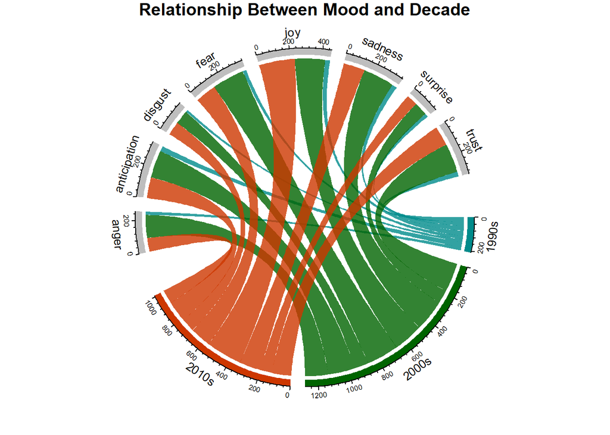

```r
grid.col = c("1990s" = "cyan4", "2000s" = "darkgreen", "2010s" = "orangered3", "anger" = "grey", "anticipation" = "grey", "disgust" = "grey", "fear" = "grey", "joy" = "grey", "sadness" = "grey", "surprise" = "grey", "trust" = "grey")

decade_mood <-  johnmayer_nrc %>%
  filter(decade != "NA" & !sentiment %in% c("positive", "negative")) %>%
  count(sentiment, decade) %>%
  group_by(decade, sentiment) %>%
  summarise(sentiment_sum = sum(n)) %>%
  ungroup()
circos.clear()
#Set the gap size
circos.par(gap.after = c(rep(5, length(unique(decade_mood[[1]])) - 1), 15,
                         rep(5, length(unique(decade_mood[[2]])) - 1), 15))
chordDiagram(decade_mood, grid.col = grid.col, transparency = .2)
title("Relationship Between Mood and Decade")
```

### On The Radar: Radar Charts

Another great way to compare sentiment across categories is to use a radar chart across decades.

```r
decade_sentiment_nrc <- johnmayer_nrc_sub %>%
  group_by(decade, sentiment) %>%
  count(decade, sentiment) %>%
  select(decade, sentiment, sentiment_decade_count = n)

#Get the total count of sentiment words per year (not distinct)
total_sentiment_decade <- johnmayer_nrc_sub %>%
  count(decade) %>%
  select(decade, decade_total = n)

#Join the two and create a percent field
decade_radar_chart <- decade_sentiment_nrc %>%
  inner_join(total_sentiment_decade, by = "decade") %>%
  mutate(percent = sentiment_decade_count / decade_total * 100 ) %>%
  select(-sentiment_decade_count, -decade_total) %>%
  spread(decade, percent) %>%
  chartJSRadar(showToolTipLabel = TRUE,
               main = "John Mayer NRC Years Radar")

decade_radar_chart
```

[interactive chart not shown]

### Mood of the song

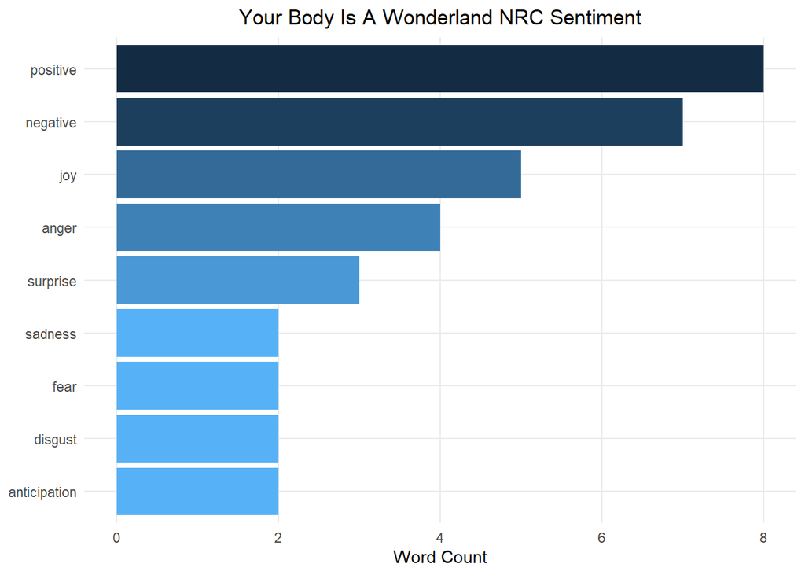

```r
# Mood of song
johnmayer_nrc %>%
  filter(song %in% "Your Body Is A Wonderland") %>%
  group_by(sentiment) %>%
  summarise(word_count = n()) %>%
  ungroup() %>%
  mutate(sentiment = reorder(sentiment, word_count)) %>%
  ggplot(aes(sentiment, word_count, fill = -word_count)) +
  geom_col() +
  guides(fill = FALSE) +
  theme_minimal() + theme_lyrics() +
  labs(x = NULL, y = "Word Count") +
  ggtitle("Your Body Is A Wonderland NRC Sentiment") +
  coord_flip()
```

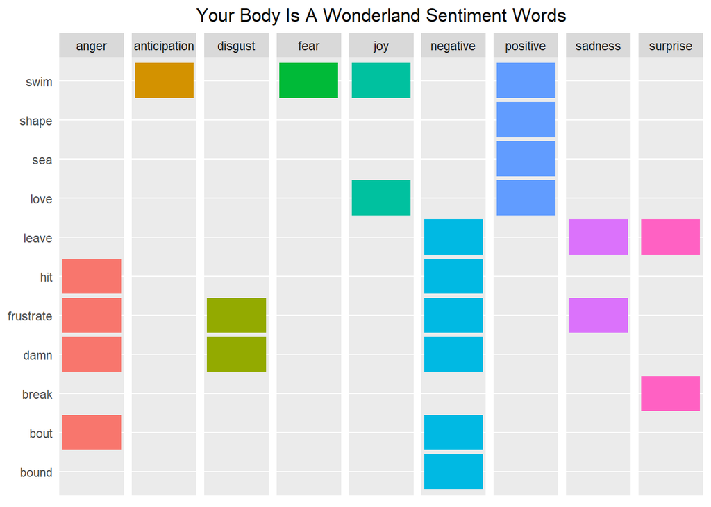

```r
johnmayer_tidy %>%
  filter(song %in% 'Your Body Is A Wonderland') %>%
  distinct(word) %>%
  inner_join(get_sentiments("nrc")) %>%
  ggplot(aes(x = word, fill = sentiment)) +
  facet_grid(~sentiment) +
  geom_bar() + #Create a bar for each word per sentiment
  theme_lyrics() +
  theme(panel.grid.major.x = element_blank(),
        axis.text.x = element_blank()) + #Place the words on the y-axis
  xlab(NULL) + ylab(NULL) +
  ggtitle("Your Body Is A Wonderland Sentiment Words") +
  coord_flip()
```

### Bigrams Per Decade

```r
johnmayer_bigrams <- johnmayer_data %>%
  unnest_tokens(bigram, lyrics, token = "ngrams", n = 2)

bigrams_separated <- johnmayer_bigrams %>%
  separate(bigram, c("word1", "word2"), sep = " ")

bigrams_filtered <- bigrams_separated %>%
  filter(!word1 %in% stop_words$word) %>%
  filter(!word2 %in% stop_words$word) %>%
  filter(!word1 %in% undesirable_words) %>%
  filter(!word2 %in% undesirable_words)

#Because there is so much repetition in music, also filter out the cases where the two words are the same
bigram_decade <- bigrams_filtered %>%
  filter(word1 != word2) %>%
  filter(decade != "NA") %>%
  unite(bigram, word1, word2, sep = " ") %>%
  inner_join(johnmayer_data) %>%
  count(bigram, decade, sort = TRUE) %>%
  group_by(decade) %>%
  slice(seq_len(10)) %>%
  ungroup() %>%
  arrange(decade, n) %>%
  mutate(row = row_number())
```

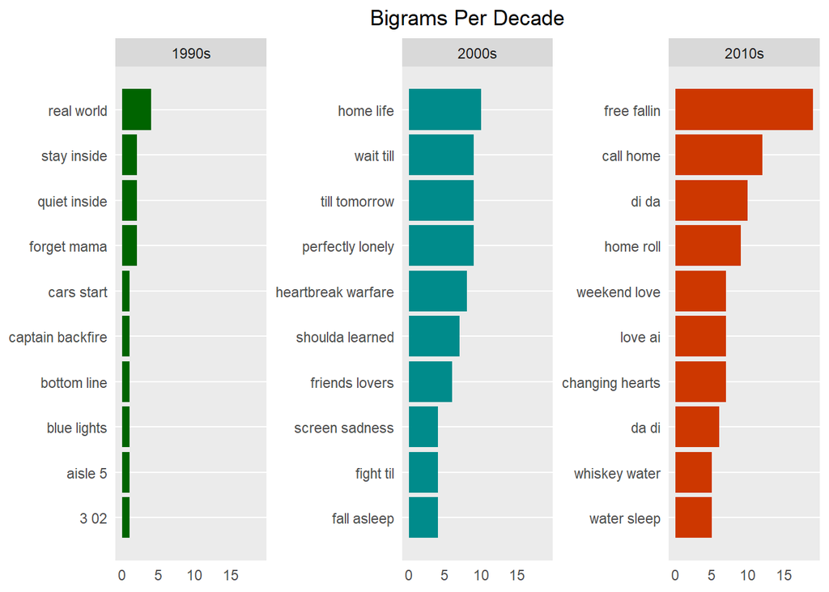

```r
bigram_decade %>%
  ggplot(aes(row, n, fill = decade)) +
  geom_col(show.legend = FALSE) +
  facet_wrap(~decade, scales = "free_y") +
  xlab(NULL) + ylab(NULL) +
  scale_x_continuous(  # This handles replacement of row
    breaks = bigram_decade$row, # Notice need to reuse data frame
    labels = bigram_decade$bigram) +
  theme_lyrics() +
  theme(panel.grid.major.x = element_blank()) +
  ggtitle("Bigrams Per Decade") +
  scale_fill_manual(values = c("1990s" = "darkgreen", "2000s" = "cyan4", "2010s" = "orangered3")) +
  coord_flip()
```

### Sentiments and Bigrams

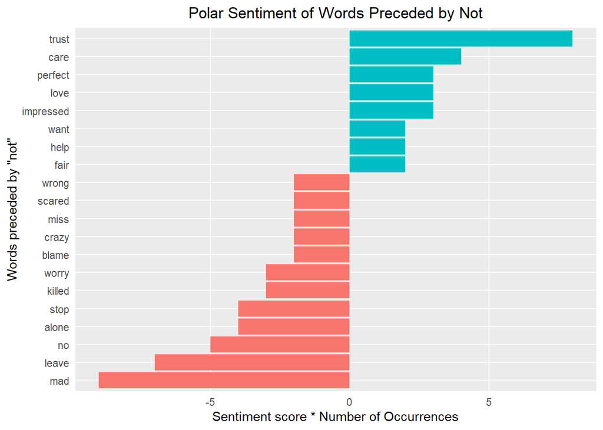

```r
AFINN <- get_sentiments("afinn")

not_words <- bigrams_separated %>%
  filter(word1 == "not") %>%
  inner_join(AFINN, by = c(word2 = "word")) %>%
  count(word2, value, sort = TRUE) %>%
  ungroup()

not_words %>%
  mutate(contribution = n * value) %>%
  arrange(desc(abs(contribution))) %>%
  head(20) %>%
  mutate(word2 = reorder(word2, contribution)) %>%
  ggplot(aes(word2, n * value, fill = n * value > 0)) +
  geom_col(show.legend = FALSE) +
  theme_lyrics() +
  xlab("Words preceded by \"not\"") +
  ylab("Sentiment score * Number of Occurrences") +
  ggtitle("Polar Sentiment of Words Preceded by Not") +
  coord_flip()
```

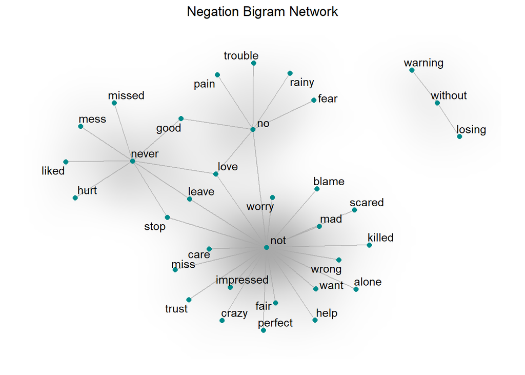

```r
negation_words <- c("not", "no", "never", "without")

negation_bigrams <- bigrams_separated %>%
  filter(word1 %in% negation_words) %>%
  inner_join(AFINN, by = c(word2 = "word")) %>%
  count(word1, word2, value, sort = TRUE) %>%
  mutate(contribution = n * value) %>%
  arrange(desc(abs(contribution))) %>%
  group_by(word1) %>%
  slice(seq_len(20)) %>%
  arrange(word1,desc(contribution)) %>%
  ungroup()

bigram_graph <- negation_bigrams %>%
  graph_from_data_frame() #From `igraph`

set.seed(123)

a <- grid::arrow(type = "closed", length = unit(.15, "inches"))

ggraph(bigram_graph, layout = "fr") +
  geom_edge_link(alpha = .25) +
  geom_edge_density(aes(fill = value)) +
  geom_node_point(color = "cyan4", size = 2) +
  geom_node_text(aes(label = name),  repel = TRUE) +
  theme_void() + theme(legend.position = "none",
                       plot.title = element_text(hjust = 0.5)) +
  ggtitle("Negation Bigram Network")
```

### Pairwise Correlation

```r
pwc <- johnmayer_tidy %>%
  filter(n() >= 5) %>%  #High counts
  pairwise_count(word, song, sort = TRUE) %>%
  filter(item1 %in% c("love", "body", "perfect")) %>%
  group_by(item1) %>%
  slice(seq_len(10)) %>%
  ungroup() %>%
  mutate(row = -row_number()) #Descending order
```

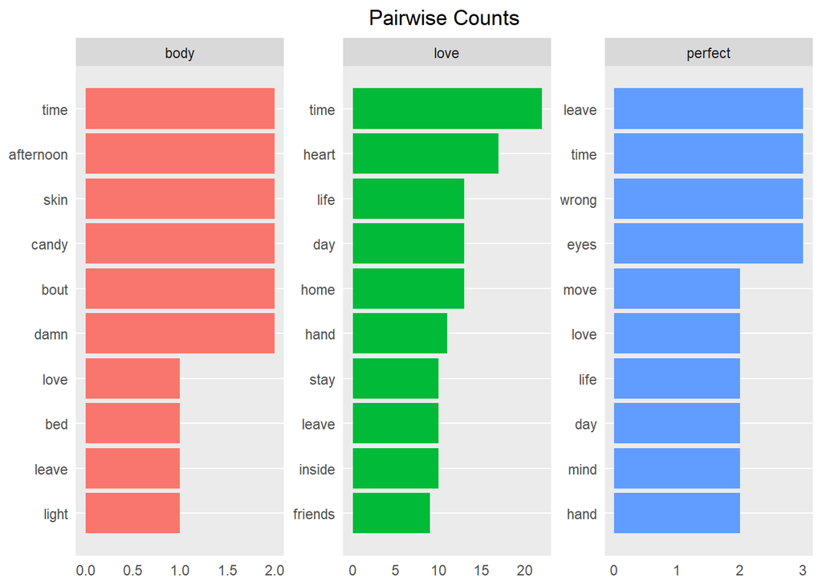

```r
pwc %>%
  ggplot(aes(row, n, fill = item1)) +
  geom_bar(stat = "identity", show.legend = FALSE) +
  facet_wrap(~item1, scales = "free") +
  scale_x_continuous(  #This handles replacement of row
    breaks = pwc$row, #Notice need to reuse data frame
    labels = pwc$item2) +
  theme_lyrics() + theme(panel.grid.major.x = element_blank()) +
  xlab(NULL) + ylab(NULL) +
  ggtitle("Pairwise Counts") +
  coord_flip()
```

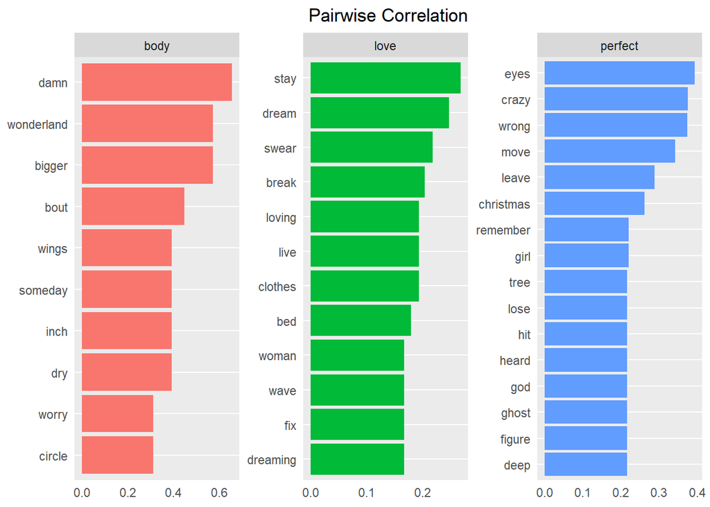

```r
johnmayer_tidy %>%
  group_by(word) %>%
  filter(n() >= 5) %>%
  pairwise_cor(word, song, sort = TRUE) %>%
  filter(item1 %in% c("love", "body", "perfect")) %>%
  group_by(item1) %>%
  top_n(10) %>%
  ungroup() %>%
  mutate(item2 = reorder(item2, correlation)) %>%
  ggplot(aes(item2, correlation, fill = item1)) +
  geom_bar(stat = 'identity', show.legend = FALSE) +
  facet_wrap(~item1, scales = 'free') +
  theme_lyrics() + theme(panel.grid.major.x = element_blank()) +
  xlab(NULL) + ylab(NULL) +
  ggtitle("Pairwise Correlation") +
  coord_flip()
```

### TOPIC Modelling

Here are several applications of topic modeling:

1. Document summaries: Use topic models to understand and summarize scientific articles enabling faster research and development. The same applies to historical documents, newspapers, blogs, and even fiction.
2. Text classification: Topic modeling can improve classification by grouping similar words together in topics rather than using each word as an individual feature.
3. Recommendation Systems: Using probabilities based on similarity, you can build recommendation systems. You could recommend articles for readers with a topic structure similar to articles they have already read.

Visualization setups:

```r
word_chart <- function(data, input, title) {
  data %>%
    #set y = 1 to just plot one variable and use word as the label
    ggplot(aes(as.factor(row), 1, label = input, fill = factor(topic) )) +
    #you want the words, not the points
    geom_point(color = "transparent") +
    #make sure the labels don't overlap
    geom_label_repel(nudge_x = .2,
                     direction = "y",
                     box.padding = 0.1,
                     segment.color = "transparent",
                     size = 3) +
    facet_grid(~topic) +
    theme_lyrics() +
    theme(axis.text.y = element_blank(), axis.text.x = element_blank(),
          #axis.title.x = element_text(size = 9),
          panel.grid = element_blank(), panel.background = element_blank(),
          panel.border = element_rect("lightgray", fill = NA),
          strip.text.x = element_text(size = 9)) +
    labs(x = NULL, y = NULL, title = title) +
    #xlab(NULL) + ylab(NULL) +
    #ggtitle(title) +
    coord_flip()
}
```

### Model Four: LDA for John Mayer Songs

The main goal of topic modeling is finding significant thematically related terms (topics) in unstructured textual data measured as patterns of word co-occurrence. The basic components of topic models are documents, terms, and topics. Latent Dirichlet Allocation (LDA) is an unsupervised learning method which discovers different topics underlying a collection of documents, where each document is a collection of words. LDA makes the following assumptions:

1. Every document is a combination of one or more topic(s)
2. Every topic is a mixture of words

```r
johnmayer_annotated <- read.csv("C:/Users/Dhruba/Desktop/GitHub/R - GitHub/data/johnmayer_data_annotated.csv", stringsAsFactors = FALSE)
names(johnmayer_annotated)
```

```
## [1] "id"    "word"  "lemma" "upos"
```

```r
table(johnmayer_annotated$upos)
```

```
##
##   ADJ   ADP   ADV   ASJ   AUX  NOUN   NUM  PART  PRON PROPN SCONJ  upos  VERB
##   306    38    94     1     9  1455     8     5    14     6     6     7   929
##     X
##     6
```

### Set Variables Using NLP

```r
# Set Variables Using NLP
source_tidy <- johnmayer_annotated %>%
  select(song = id, word, lemma, upos) %>%
  filter(upos == "NOUN") %>% #choose only the nouns
  inner_join(johnmayer_tidy, by = c("word", "song")) %>%
  select(song, word, lemma, upos, year) %>%
  mutate(source = "johnmayer")%>%
  mutate(genre = "bluesrock") %>%
  distinct()

source_dtm <- source_tidy %>%
  #filter out some words that exist across themes just for our purposes
  filter(!word %in% c("love", "perfect", "body", "night", "girl")) %>%
  count(song, word, sort = TRUE) %>%
  ungroup() %>%
  cast_dtm(song, word, n)
```

### Fit the Model and Identify Themes

```r
# Changing these parameters or the source data will cause different results!!
# use the GIBBS sampling method.
k <- 5
num_words <- 6
seed = 4321
lda <- LDA(source_dtm, k = k, method = "GIBBS", control = list(seed = seed))
```

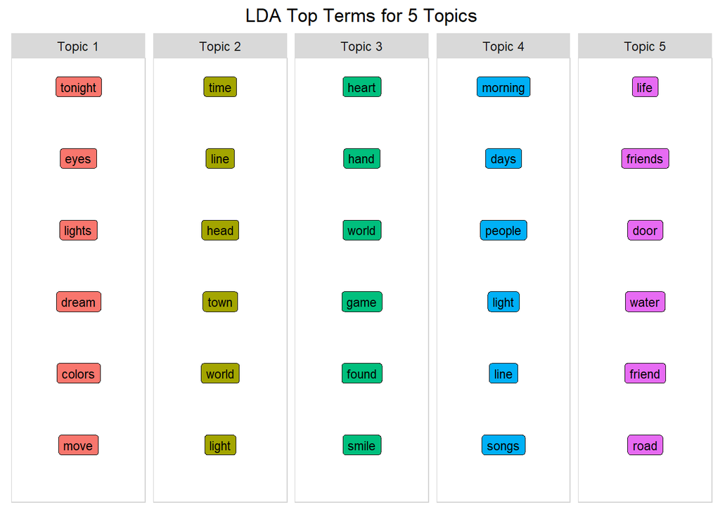

```r
top_terms_per_topic <- function(lda_model, num_words) {

  #tidy LDA object to get word, topic, and probability (beta)
  topics_tidy <- tidy(lda_model, matrix = "beta")


  top_terms <- topics_tidy %>%
    group_by(topic) %>%
    arrange(topic, desc(beta)) %>%
    #get the top num_words PER topic
    slice(seq_len(num_words)) %>%
    arrange(topic, beta) %>%
    #row is required for the word_chart() function
    mutate(row = row_number()) %>%
    ungroup() %>%
    #add the word Topic to the topic labels
    mutate(topic = paste("Topic", topic, sep = " "))
  #create a title to pass to word_chart
  title <- paste("LDA Top Terms for", k, "Topics")
  #call the word_chart function you built in prep work
  word_chart(top_terms, top_terms$term, title)
}

top_terms_per_topic(lda, num_words)
```

```r
p1 <-  johnmayer_tidy %>%
  filter(word %in% c("fallin", "head", "town","woman","neon","daughters")) %>%
  group_by(year) %>%
  mutate(topic_1_count = n()) %>%
  select(year, topic_1_count) %>%
  distinct() %>%
  ggplot(aes(year, topic_1_count)) + geom_smooth(se = FALSE, col = "darkgreen")

p2 <-  johnmayer_tidy %>%
  filter(word %in% c("heart", "friends", "loving","trust","weekend","hand")) %>%
  group_by(year) %>%
  mutate(topic_2_count = n()) %>%
  select(year, topic_2_count) %>%
  distinct() %>%
  ggplot(aes(year, topic_2_count)) + geom_smooth(se = FALSE, col = "darkgreen")

p3 <-  johnmayer_tidy %>%
  filter(word %in% c("world", "water", "found","whiskey","days","train")) %>%
  group_by(year) %>%
  mutate(topic_3_count = n()) %>%
  select(year, topic_3_count) %>%
  distinct() %>%
  ggplot(aes(year, topic_3_count)) + geom_smooth(se = FALSE, col = "darkgreen")

p4 <-  johnmayer_tidy %>%
  filter(word %in% c("light","tonight","fool","roll","tomorrow","sadness")) %>%
  group_by(year) %>%
  mutate(topic_4_count = n()) %>%
  select(year, topic_4_count) %>%
  distinct() %>%
  ggplot(aes(year, topic_4_count)) + geom_smooth(se = FALSE, col="darkgreen")

p5 <-  johnmayer_tidy %>%
  filter(word %in% c("time","life","line","living","moving","olivia")) %>%
  group_by(year) %>%
  mutate(topic_5_count = n()) %>%
  select(year, topic_5_count) %>%
  distinct() %>%
  ggplot(aes(year, topic_5_count)) + geom_smooth(se = FALSE, col="darkgreen")

#grid.arrange(p1, p2, p3, p4, p5, ncol = 2)
```

This is an extremely rudimentary example of how themes change over time, but still shows the trend right?

### FINAL CONCLUSION

The following concludes the top 5 changing thems over time of John Mayer songs. Also the following represents the popularity of his songs over decades.

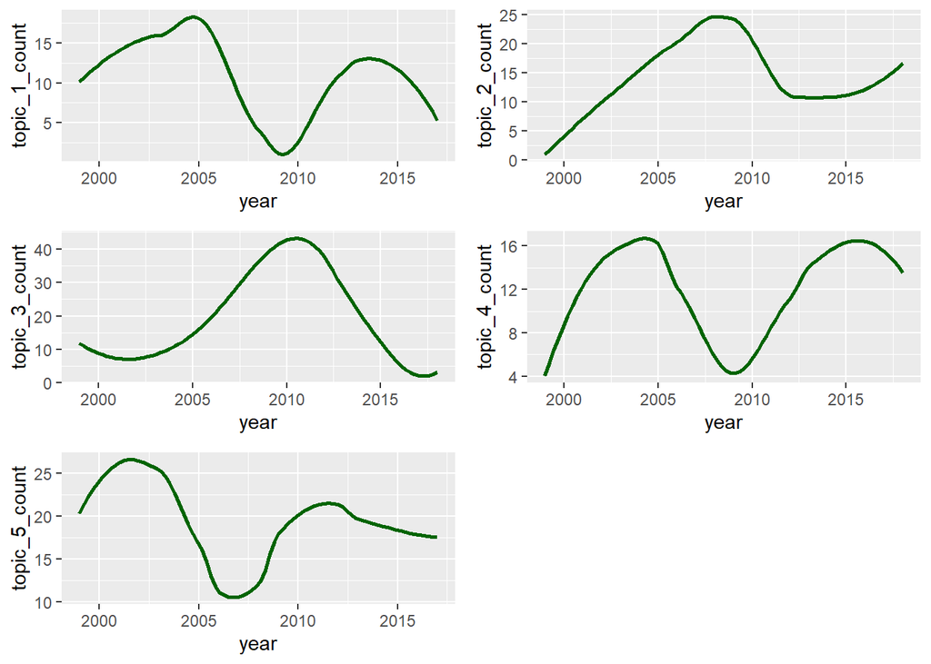

```r
grid.arrange(p1, p2, p3, p4, p5, ncol = 2)
```

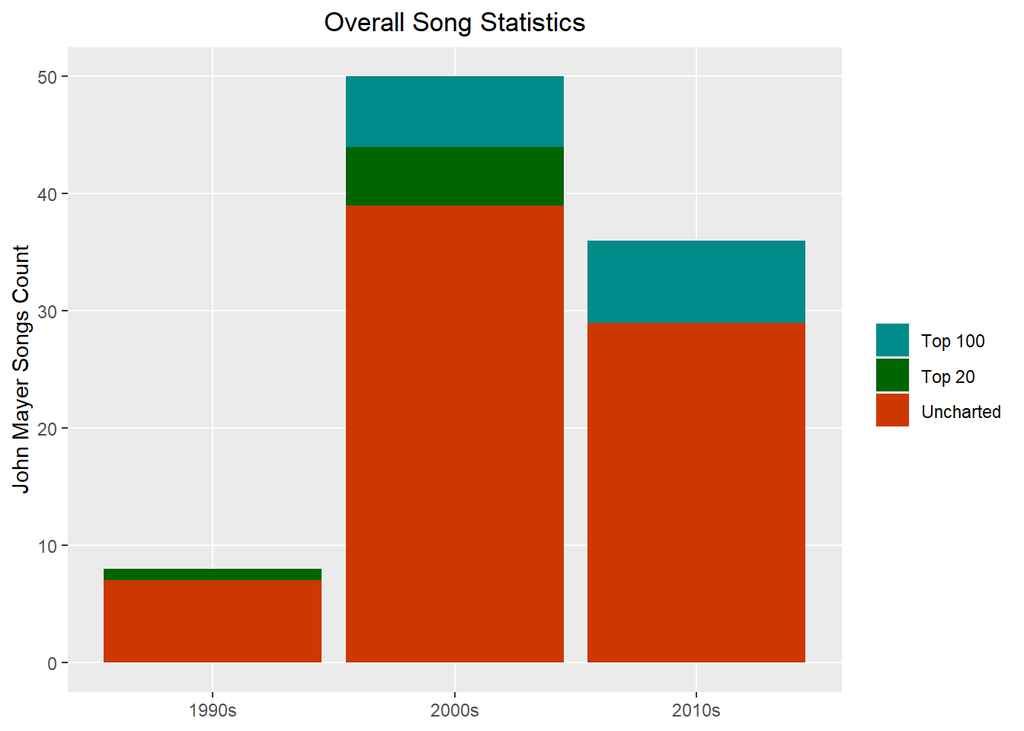

```r
## Song-Stats: Overall Dataset
johnmayer %>%
  group_by(decade, chart_level) %>%
  summarise(number_of_songs = n()) %>%
  ggplot() +
  geom_bar(aes(x = decade, y = number_of_songs,
               fill = chart_level), stat = "identity")  +
  theme(plot.title = element_text(hjust = 0.5),
        legend.title = element_blank(),
        panel.grid.minor = element_blank()) +
  scale_fill_manual("legend", values = c("Top 20" = "darkgreen", "Top 100" = "cyan4", "Uncharted" = "orangered3")) +
  labs(x = NULL, y = "John Mayer Songs Count") +
  ggtitle("Overall Song Statistics")
```

Potential reasons for less Top 20 songs?